# R4DS_2E_exploratoryDataAnalysis

Martin

2026-01-19

## Exploratory data analysis - Unusual values

1. Explore the distribution of each of the x, y, and z variables in diamonds. What do you learn? Think about a diamond and how you might decide which dimension is the length, width, and depth.

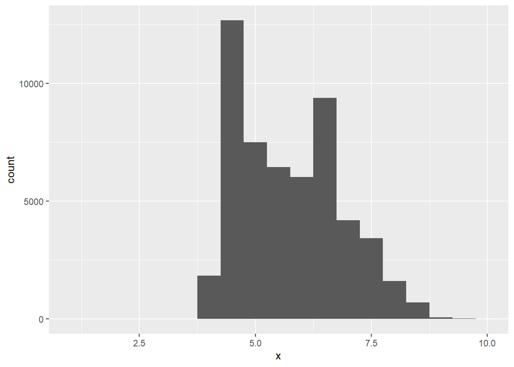

```r
# I would expect diamonds to have similar lengths and widths due to their overall symmetry and maybe a higher depth in respect to length and width. My first thought is that x and y are length and width respectively and z will be depth.

ggplot(diamonds, aes(x = x)) +
  geom_histogram(binwidth = 0.5) +
  xlim(c(1, 10))
```

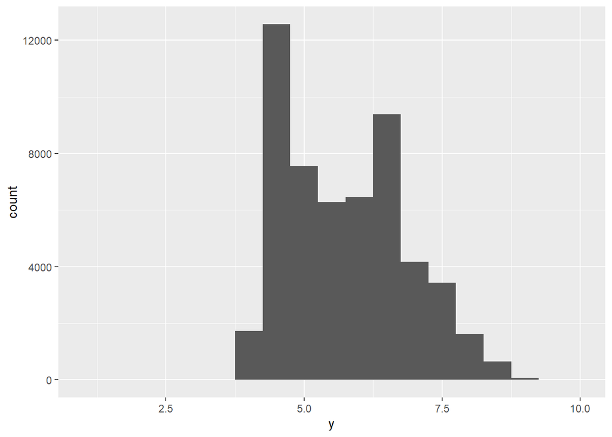

```r
ggplot(diamonds, aes(x = y)) +
  geom_histogram(binwidth = 0.5) +
  xlim(c(1, 10))
```

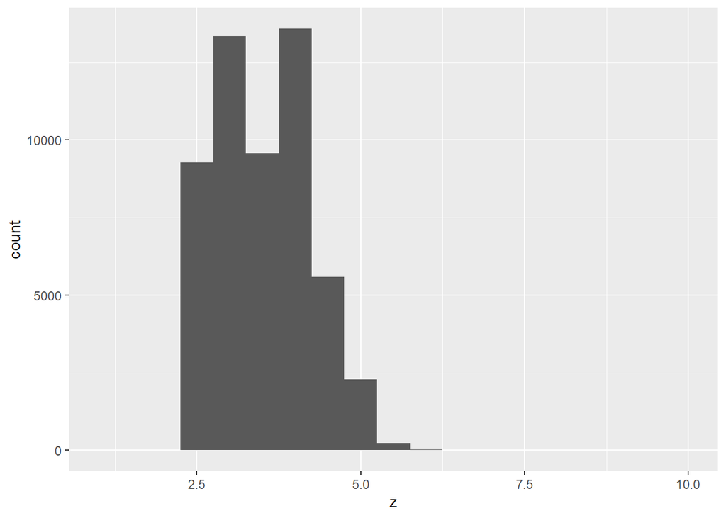

```r
ggplot(diamonds, aes(x = z)) +
  geom_histogram(binwidth = 0.5) +
  xlim(c(1, 10))
```

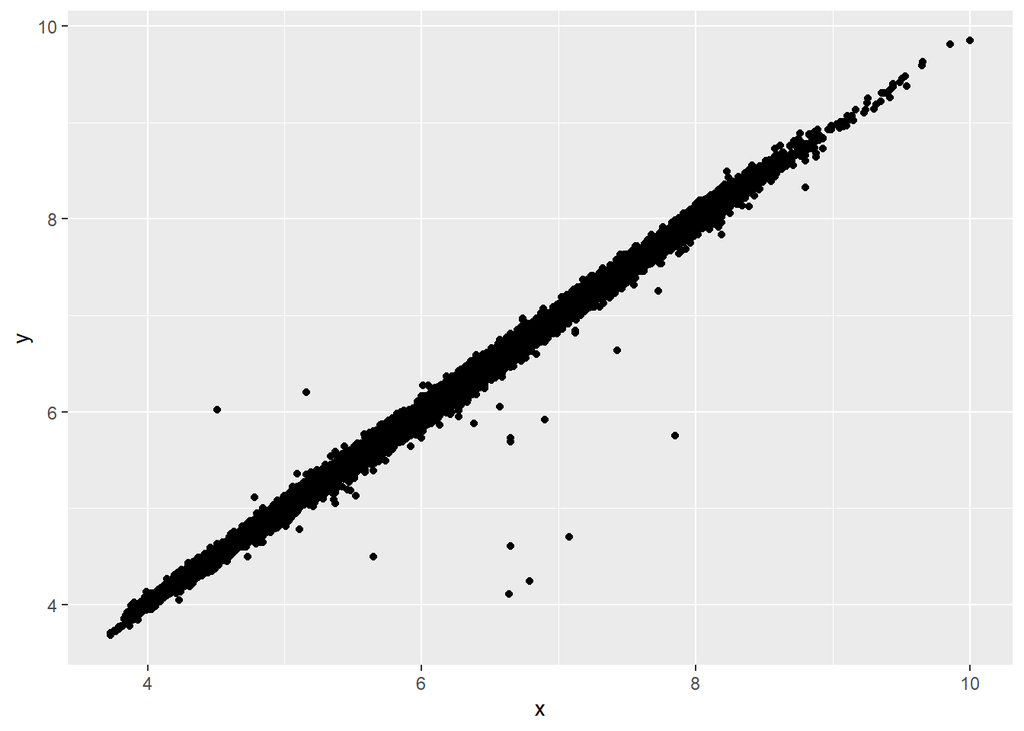

```r
# Both plots of x and y counts are extremely similar, which suggests that x and y are length and width respectively. The values for z suprise me a little then what I invisioned. Looks like the depth of diamonds are slightly lower than that of the length and width of the diamond.

diamonds |>
  filter(between(y, 1, 10) & between(x, 1, 10)) |>
  ggplot(aes(x = x, y = y)) +
    geom_point()
```

2. Explore the distribution of price. Do you discover anything unusual or surprising? (Hint: Carefully think about the binwidth and make sure you try a wide range of values.)

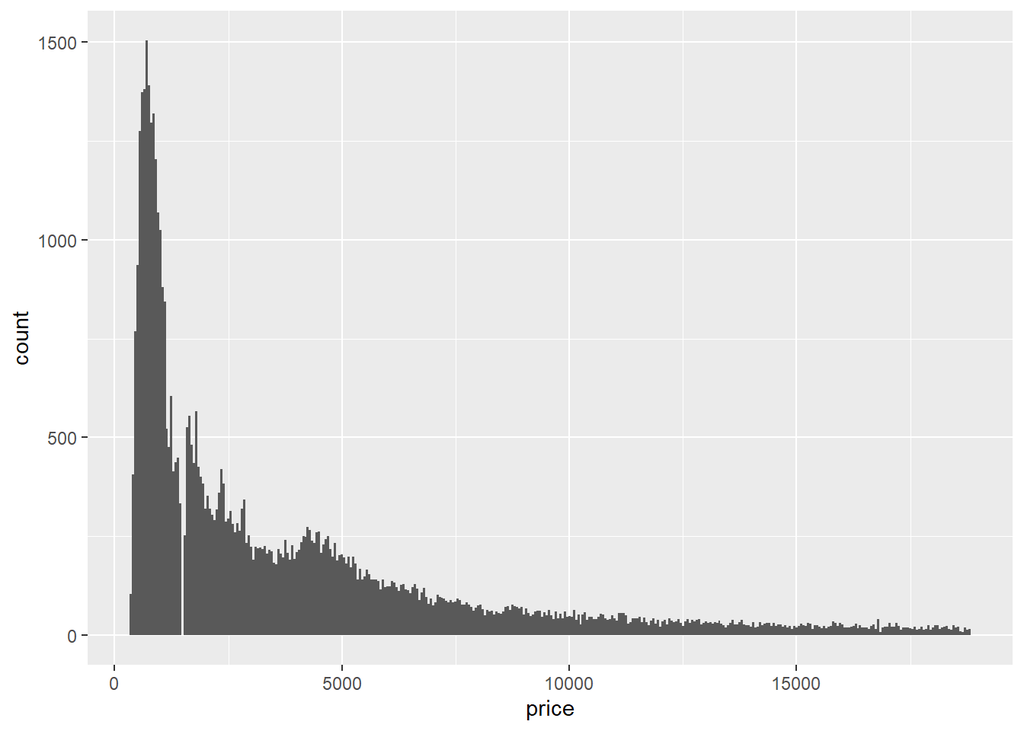

```r
ggplot(diamonds, aes(x = price)) +
  geom_histogram(binwidth = 50)
```

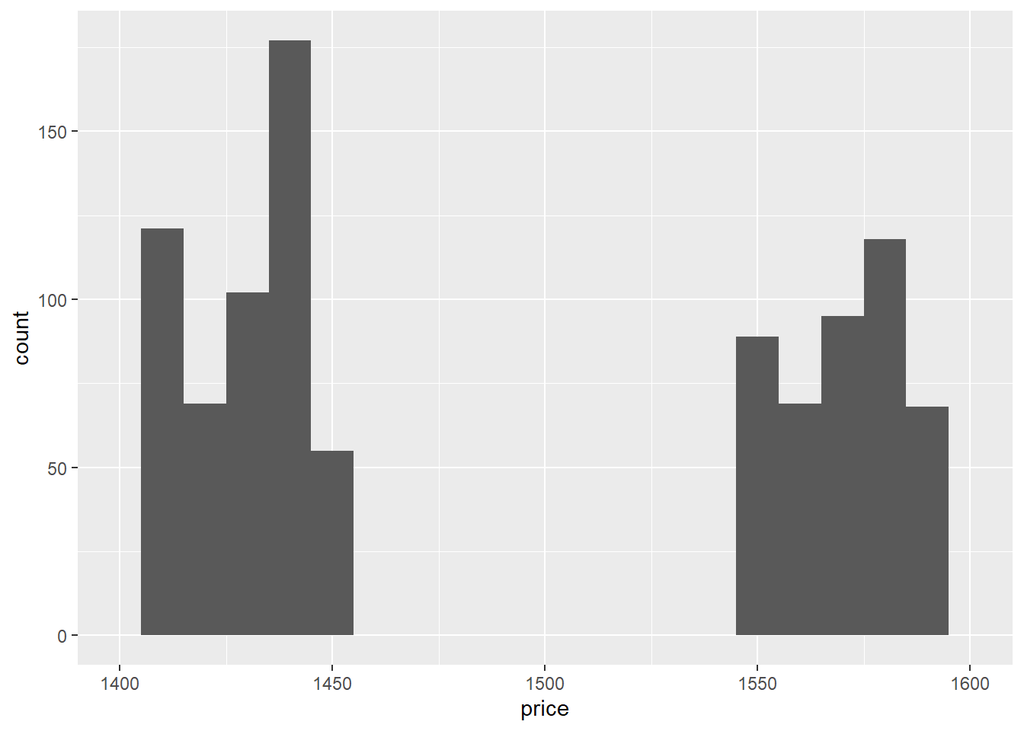

```r
# The above shows an unusual dip somewhere between 0-2500 in price. Lets try zoom in on it

ggplot(diamonds, aes(x = price)) +
  geom_histogram(binwidth = 10) +
  xlim(c(1400, 1600))
```

```r
# It appears no prices are between 1460-1540 in terms of price. This is strange. Some sort of follow up would be needed as to why this is the case.
```

3. How many diamonds are 0.99 carat? How many are 1 carat? What do you think is the cause of the difference?

```r
diamonds |>
  summarize(
    n = n(),
    .by = carat
  ) |>
  filter(carat %in% c(0.99, 1))
```

```
## # A tibble: 2 × 2
##   carat     n
##   <dbl> <int>
## 1  1     1558
## 2  0.99    23
```